# Erreurs simulations débourrement SUWE

Gabriel Macé

2025-03-31

## Objectifs :

Suite aux erreurs constatées lors de la simulation des dates de débourrements de la parcelles vitadapt, nous avons émis les hypothèses que :

La calibration des paramètres du modèle SUWE est faite sur des données où chaque cépage est dans les régions où on le retrouve habituellement. Il y aurait une forme de sur-apprentissage : le modèle fonctionne très bien lorsque que le couple cépage / région est habituel, mais moins lorsque que ce n’est pas le cas, comme avec vitadapt. La plasticité des cépages selon la région n’est pas assez prise en compte.

Aussi les années 2015 / 2022 peuvent être atypiques.

Le but ici est vérifier ces hypothèses en comparant les simulations de débourrement via la maille SAFRAN correspondant à la station vitadapt à celle que nous allons faire pour chaque parcelle de producteur.

Nous pourrons pas vraiment ici valider notre première hypothèse car il faudrait avoir les observations de phénologies des “parcelles producteurs”. Mais nous pouvons la rejeter, elle serait fausse si les simulations de stade phénologique sur la parcelle vitadapt sont proches de celle sur les autres parcelles.

Si l’ensemble simulations sur les années 2015 et 2022 sont atypiques, alors ces années peuvent les autres sur l’ensemble de nos parcelles, sinon elles peuvent l’être uniquement sur la parcelle viadapt.

Pour garder une cohérence dans les comparaisons, toutes les simulations sont faites à partir de donénes SAFRAN.

## Simulations toutes France :

## Simulation parcelle vitadapt :

## Récupération données vitadapt :

## Comparaison :

### Débourrement :

Dans tous les boxplots qui vont suivre, les boites à moustaches principales (en noir) répresent les simulations d’un stade phénologique pour les “parcelles producteurs” (celles présentes dans notre jeu de donénes ESCA), en rouge les simulations faites sur la parcelle vitadapt, et en bleu les observations réelles de la parcelle vitadapt.

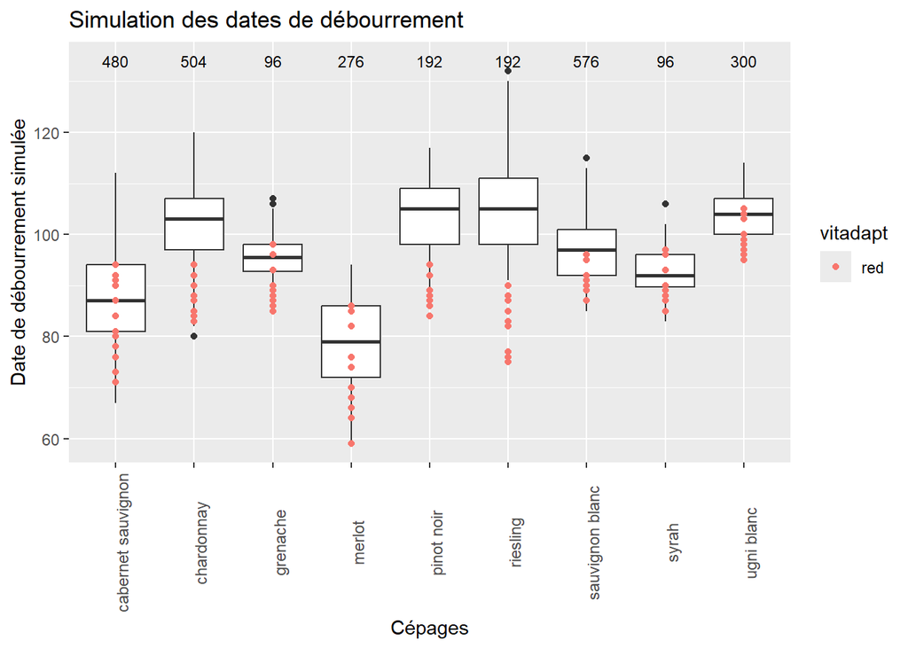

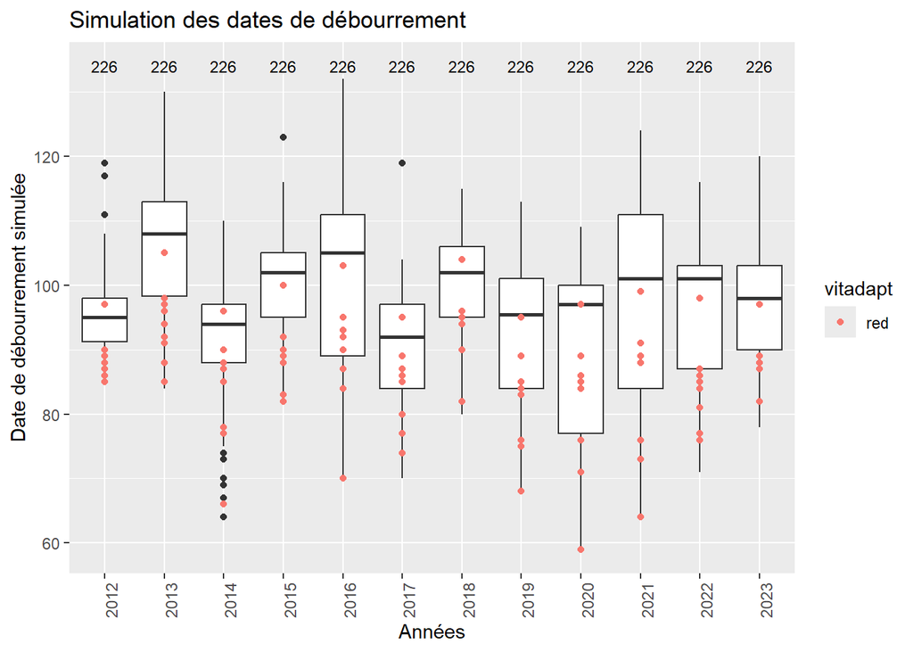

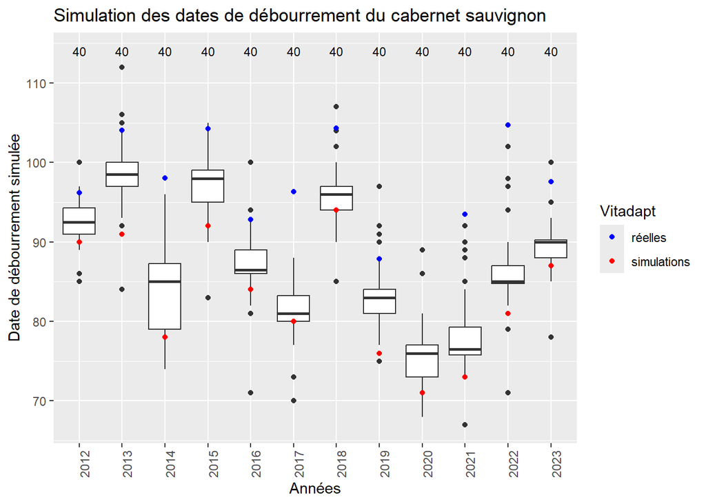

```
## [1] "cabernet sauvignon"
## [1] "Distance moyenne simulation tous - observations vitadapt : 10.7350613991182"
## [1] "Distance moyenne simulation vitadapt - observations vitadapt : 15.0600613991182"
```

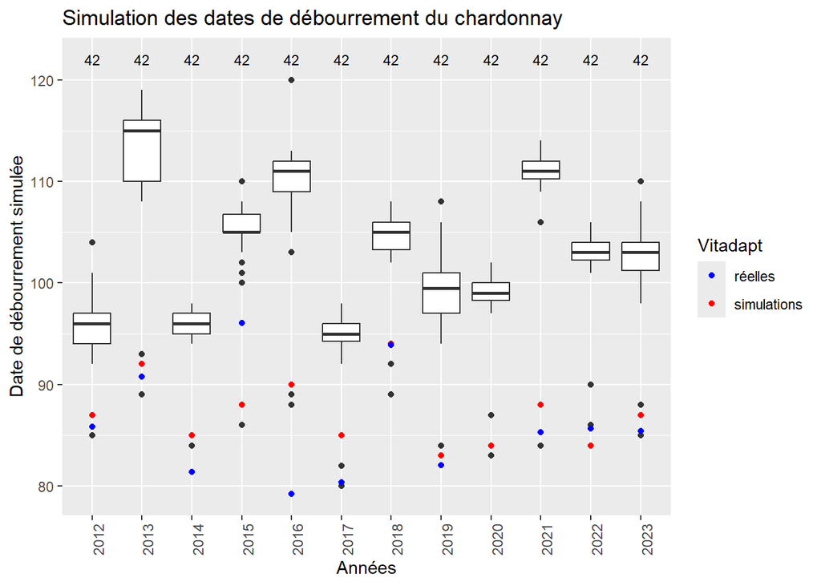

```
## [1] "chardonnay"
## [1] "Distance moyenne simulation tous - observations vitadapt : 16.5392926332696"
## [1] "Distance moyenne simulation vitadapt - observations vitadapt : 1.26151485549182"
```

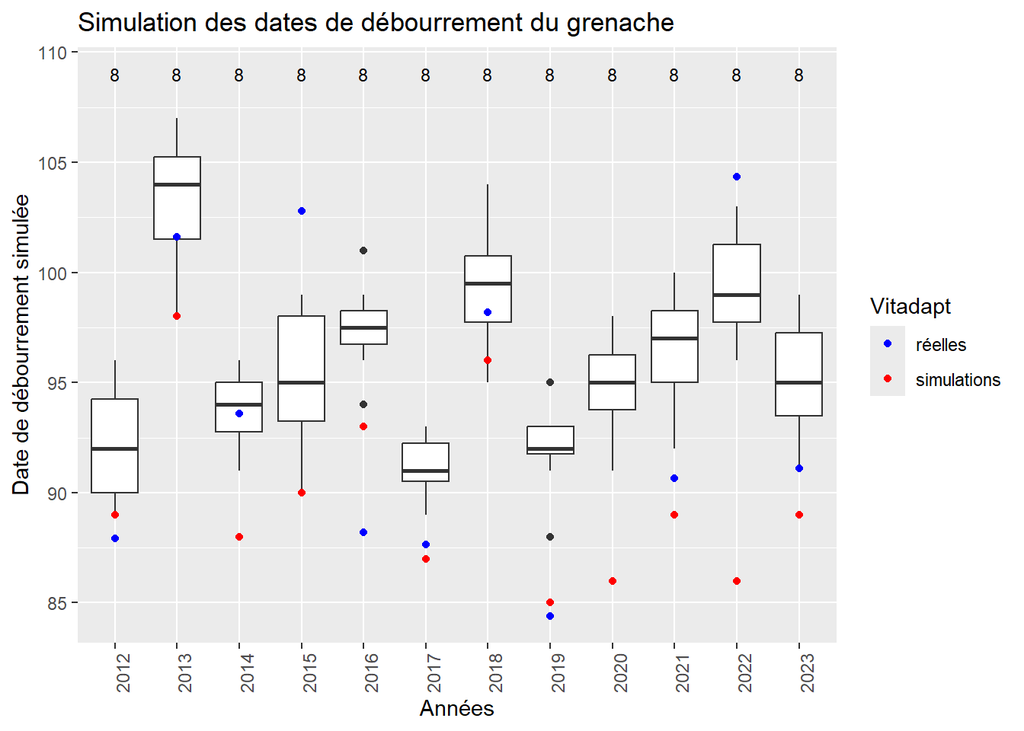

```
## [1] "grenache"
## [1] "Distance moyenne simulation tous - observations vitadapt : 2.16146156537"
## [1] "Distance moyenne simulation vitadapt - observations vitadapt : 4.01562176796332"
```

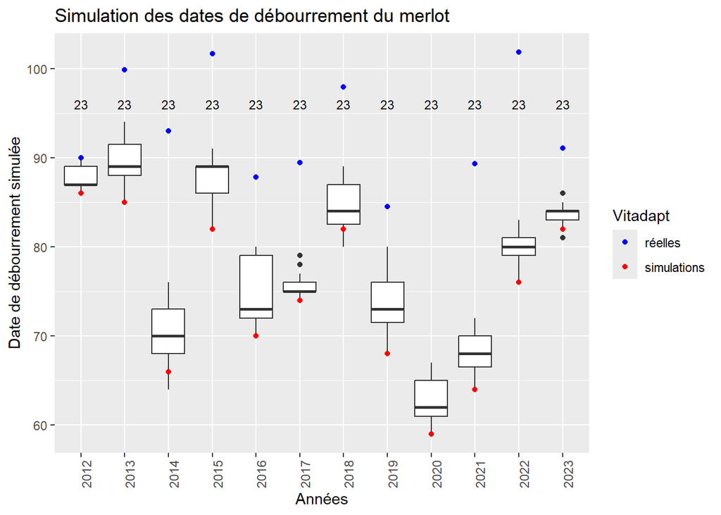

```
## [1] "merlot"
## [1] "Distance moyenne simulation tous - observations vitadapt : 15.1932371639507"
## [1] "Distance moyenne simulation vitadapt - observations vitadapt : 18.812802381342"
```

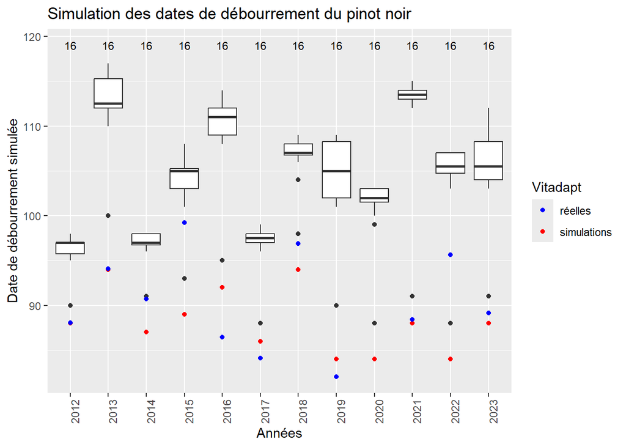

```
## [1] "pinot noir"
## [1] "Distance moyenne simulation tous - observations vitadapt : 13.7917479569247"
## [1] "Distance moyenne simulation vitadapt - observations vitadapt : 2.26033537640859"
```

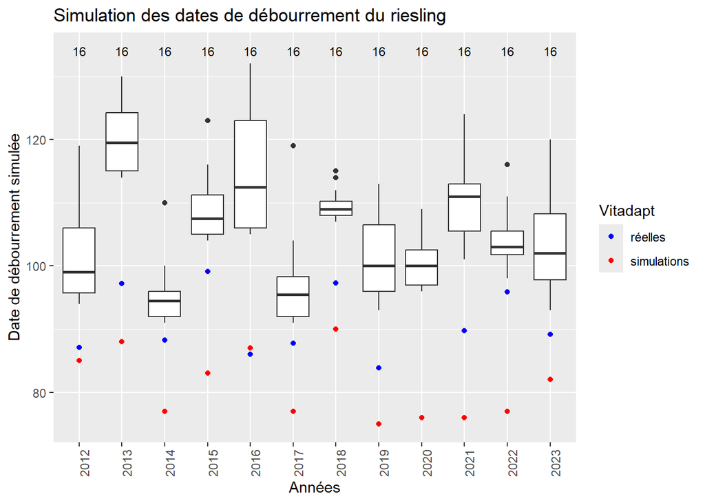

```
## [1] "riesling"
## [1] "Distance moyenne simulation tous - observations vitadapt : 14.6869719749248"
## [1] "Distance moyenne simulation vitadapt - observations vitadapt : 9.96406969174186"
```

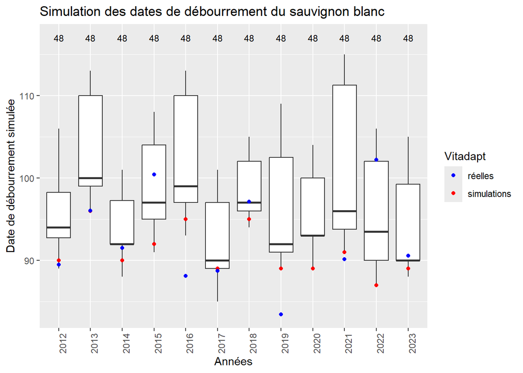

```
## [1] "sauvignon blanc"
## [1] "Distance moyenne simulation tous - observations vitadapt : 4.98775145782693"
## [1] "Distance moyenne simulation vitadapt - observations vitadapt : 1.52440131995084"
```

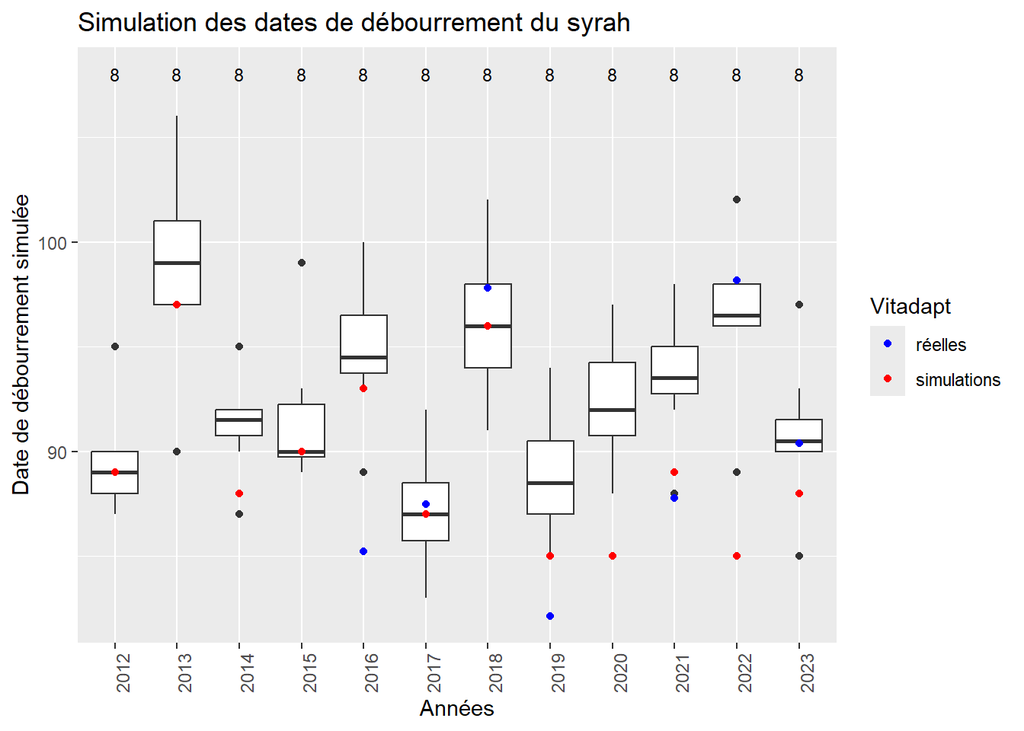

```
## [1] "syrah"
## [1] "Distance moyenne simulation tous - observations vitadapt : 2.78838809012471"
## [1] "Distance moyenne simulation vitadapt - observations vitadapt : 0.524111909875288"
```

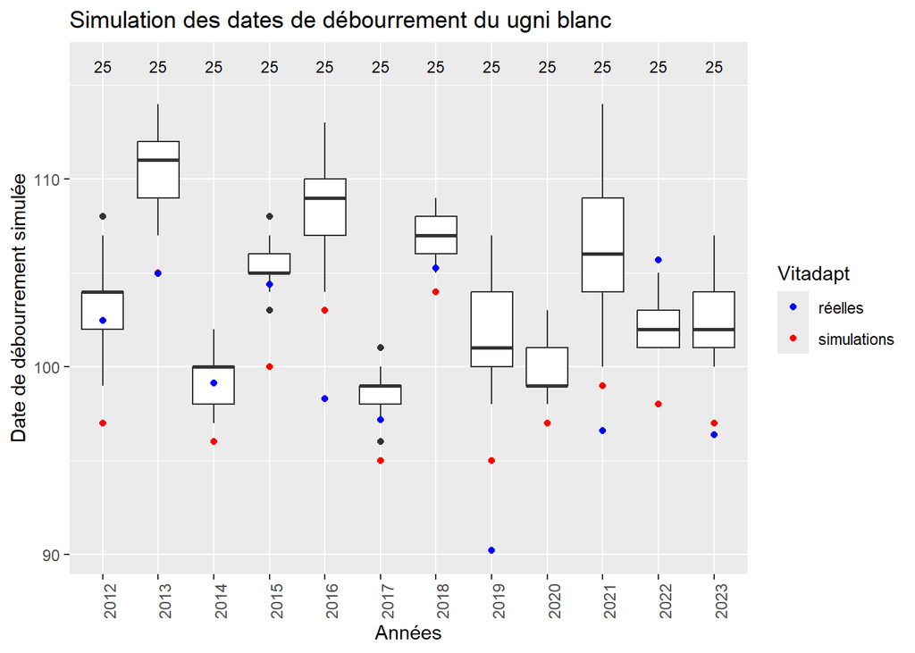

```
## [1] "ugni blanc"
## [1] "Distance moyenne simulation tous - observations vitadapt : 3.79442231499907"
## [1] "Distance moyenne simulation vitadapt - observations vitadapt : 1.21557768500094"
```

Selon le cépage, les simulations de débourrement sur les parcelles des producteurs sont plus tardives ou plus précoces que les observations vitadapt.

Pour certains cépages, les observations de débourrement sur la parcelle vitadapt semblent plus proches des simulations faites sur les parcelles des producteurs que celle faites sur la parcelle vitadapt.

Ici, étant donné que les simulations SUWE sur la parcelle vitadapt sont plus précoces que les autres simulations, cela signifie que la température quotidienne est proche de l’optimale : 26.1°-> cumul plus d’unité de chaleur -> prévisions trop précoce.

### Floraison SUWE :

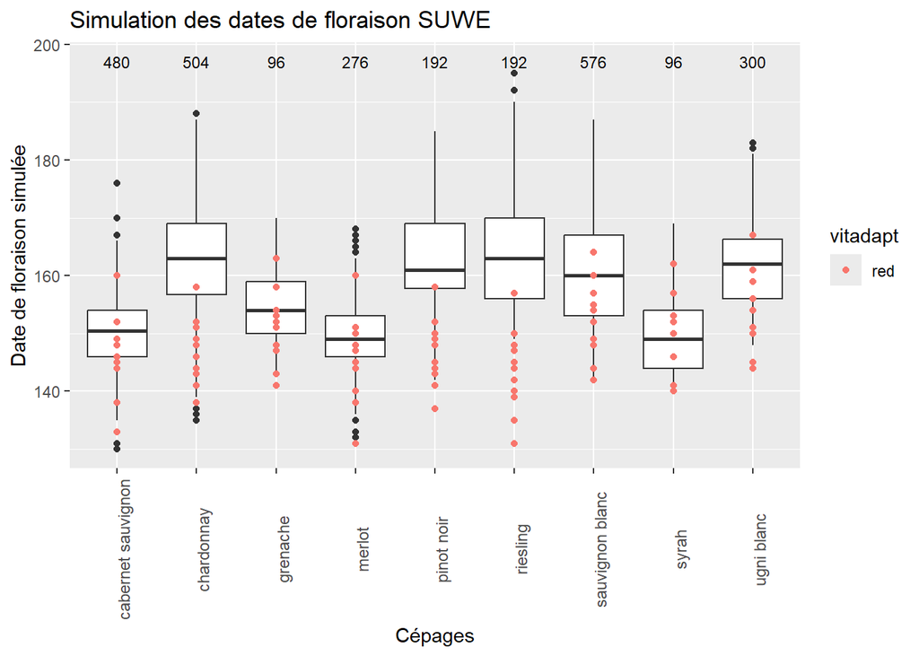

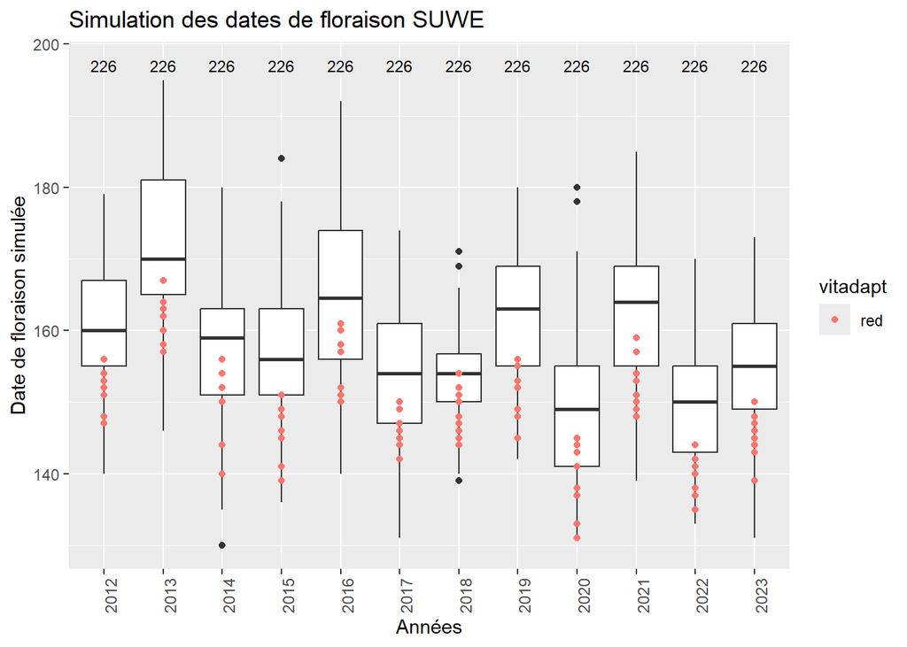

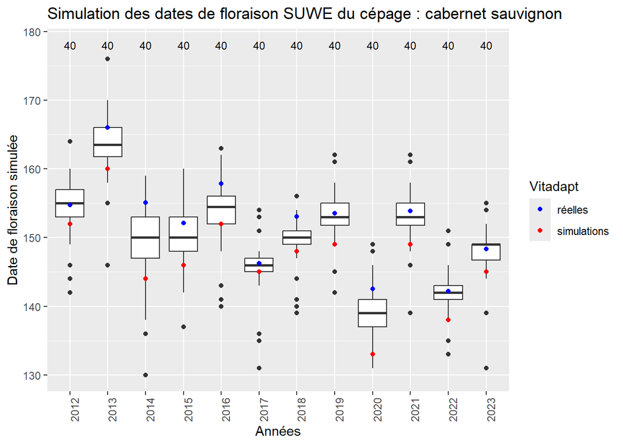

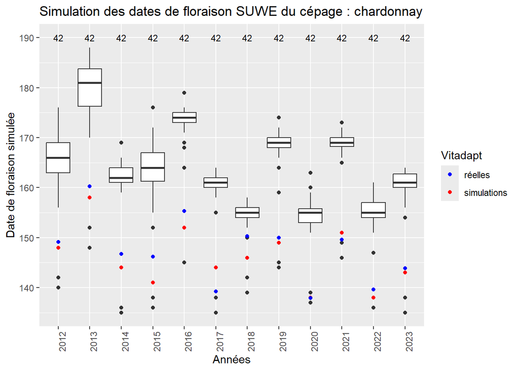

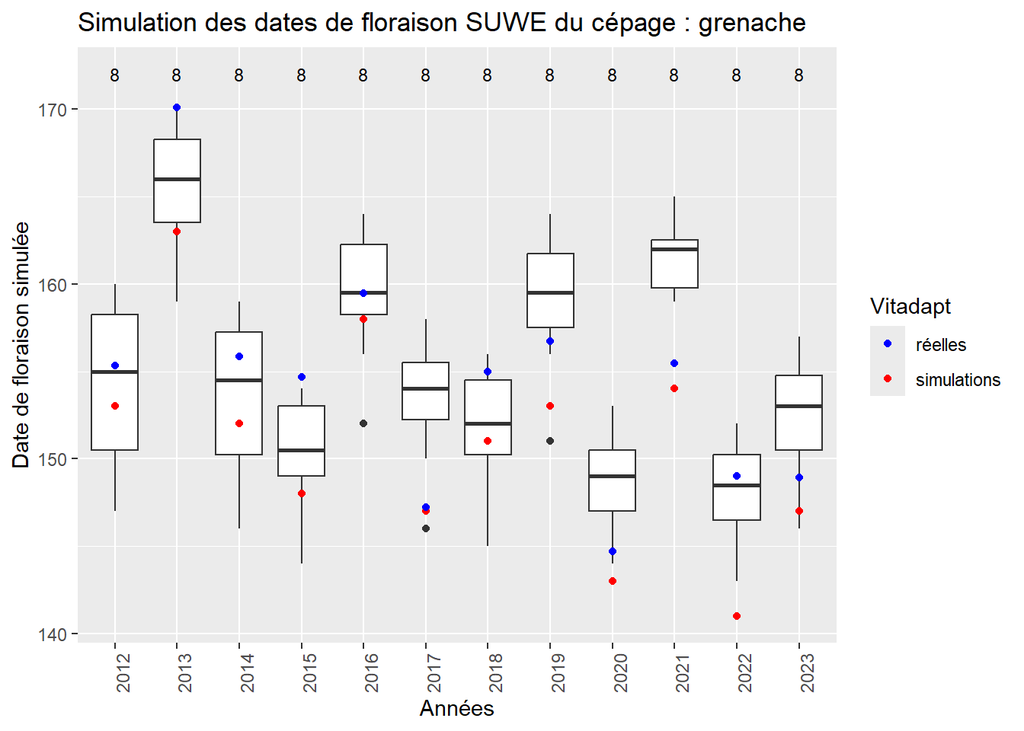

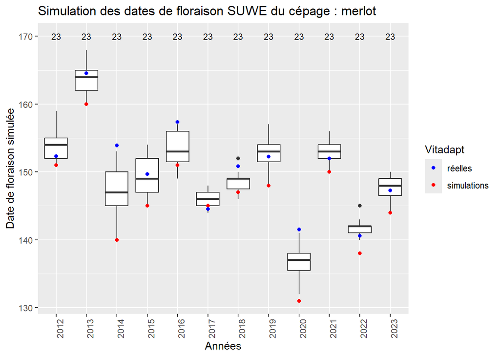

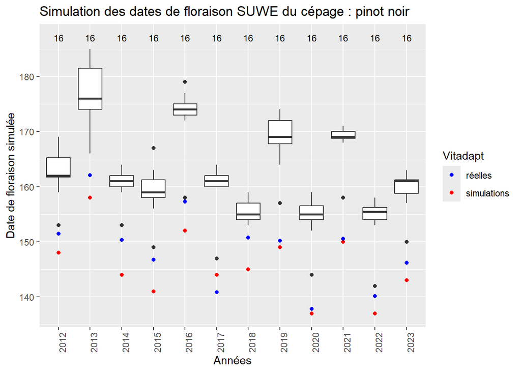

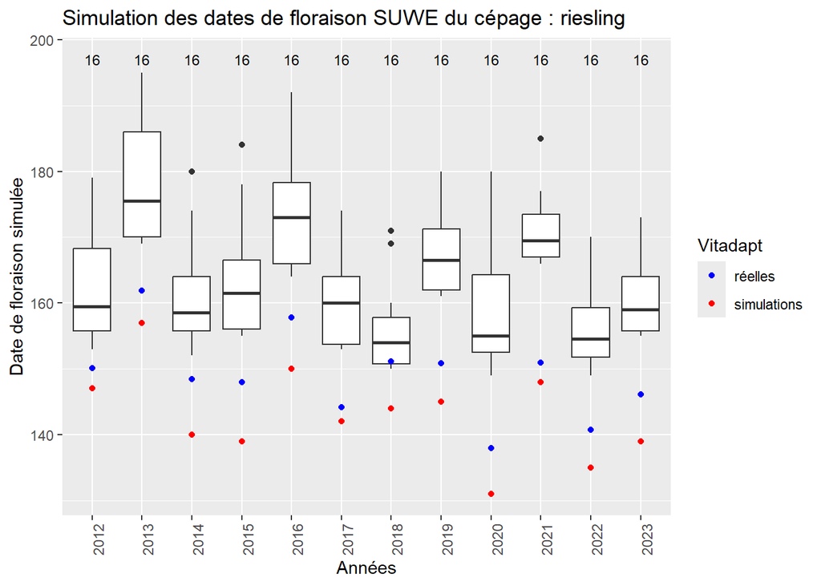

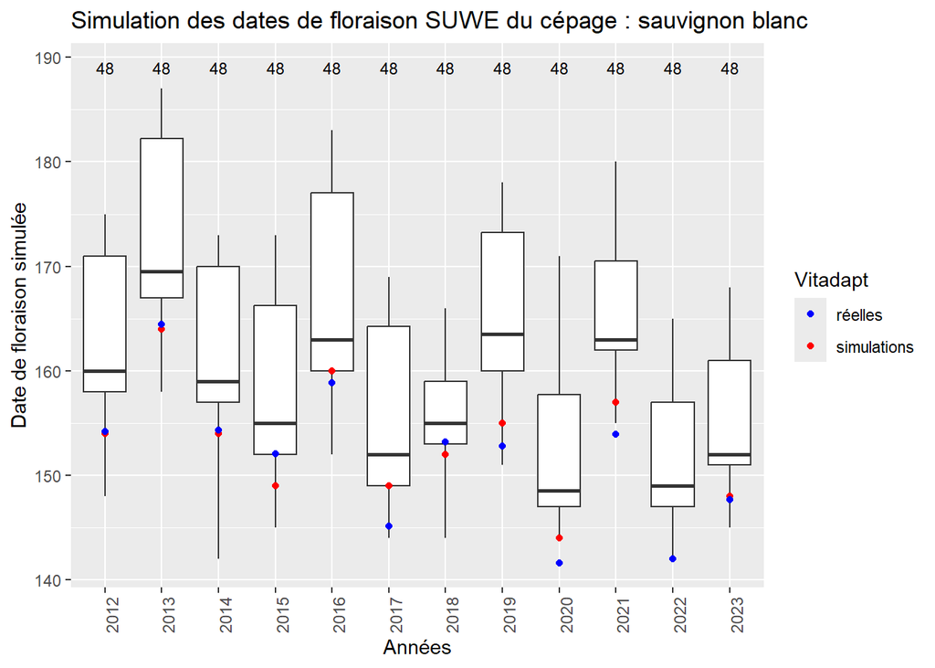

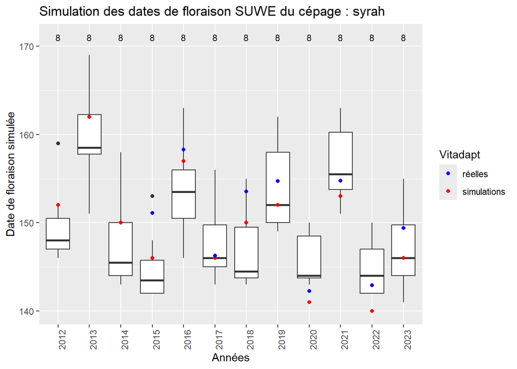

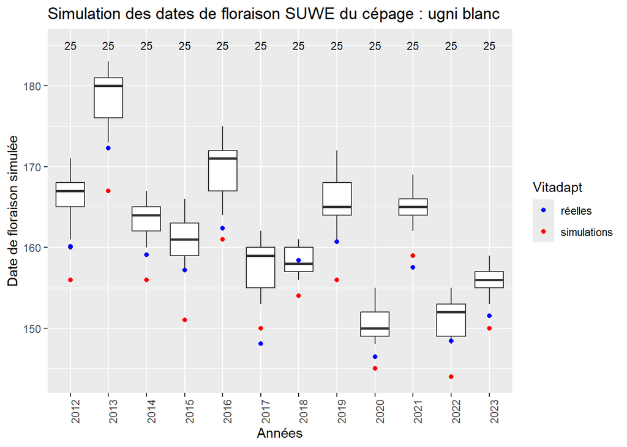

Même observation que pour le débourrement.

### Floraison gfv :

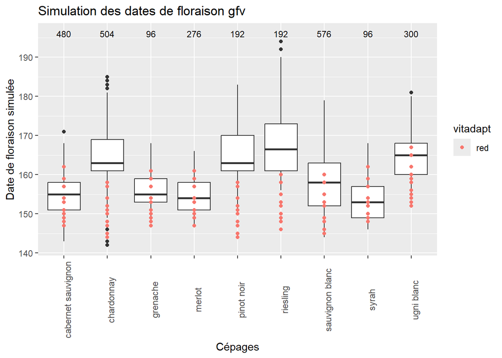

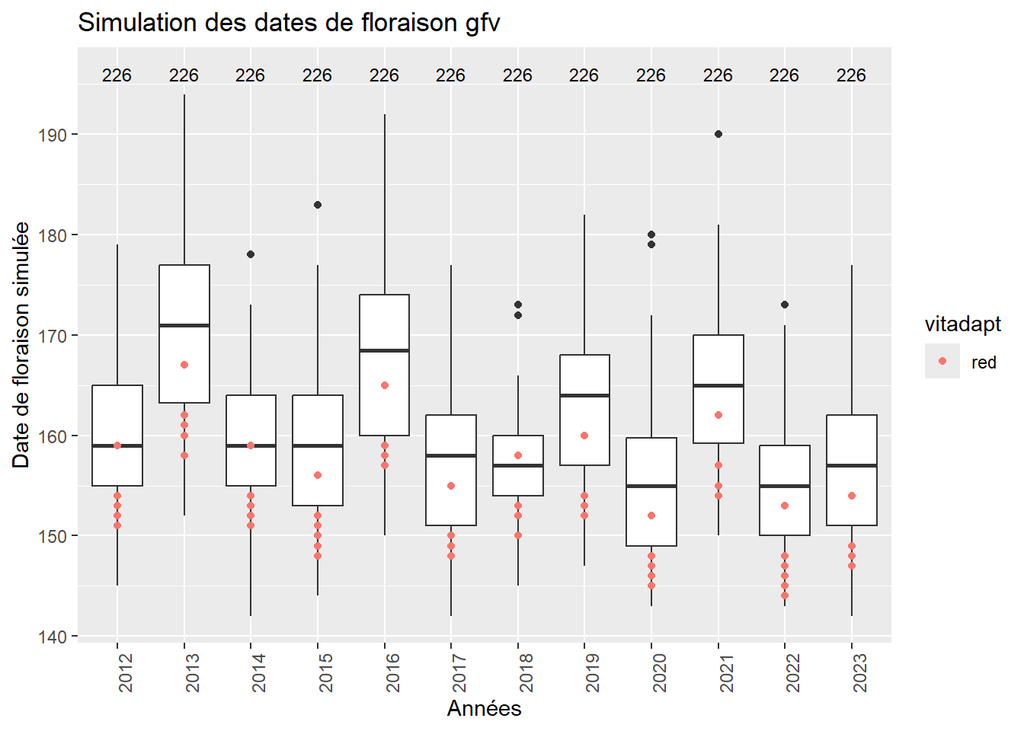

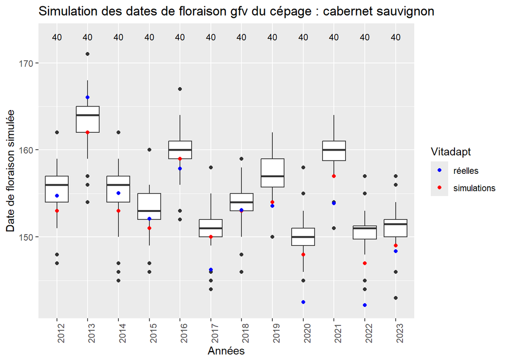

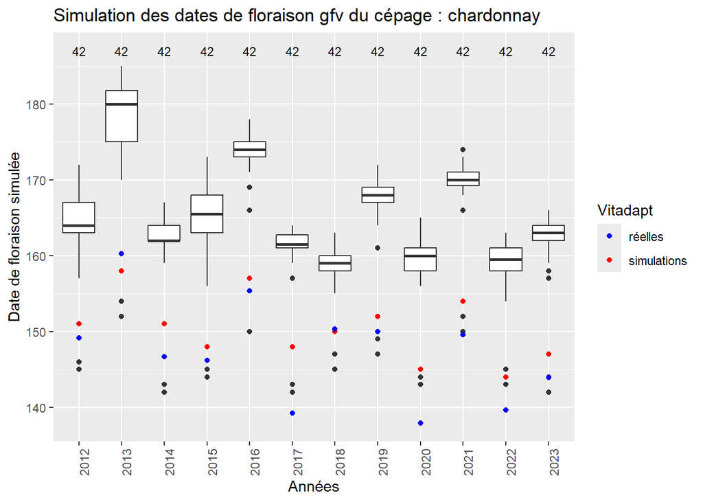

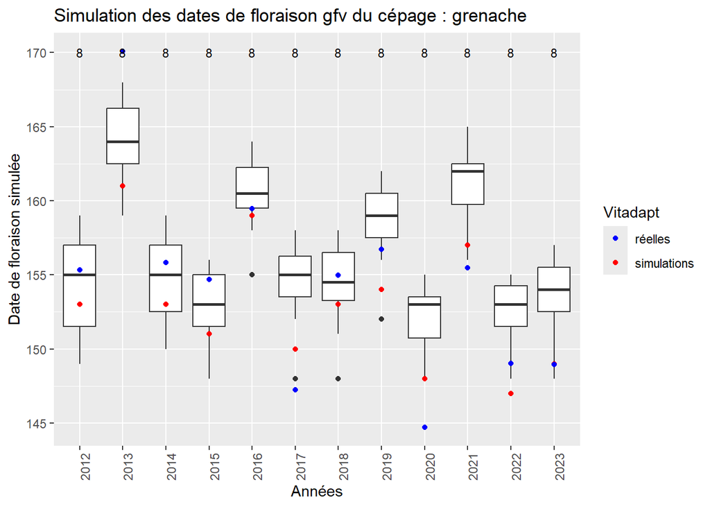

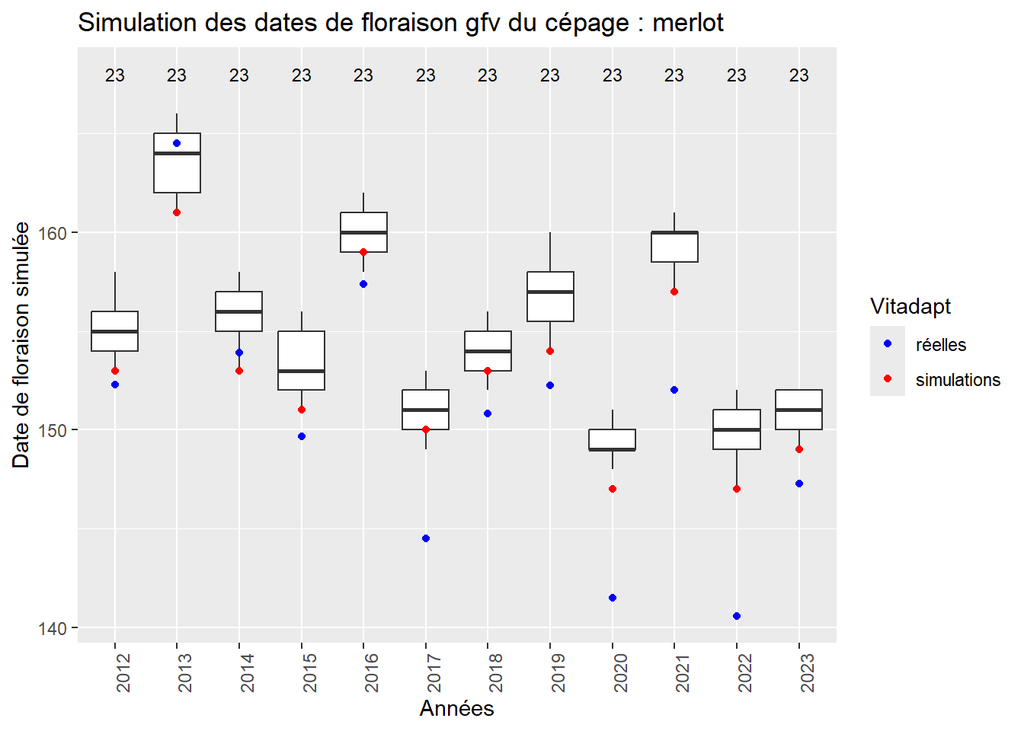

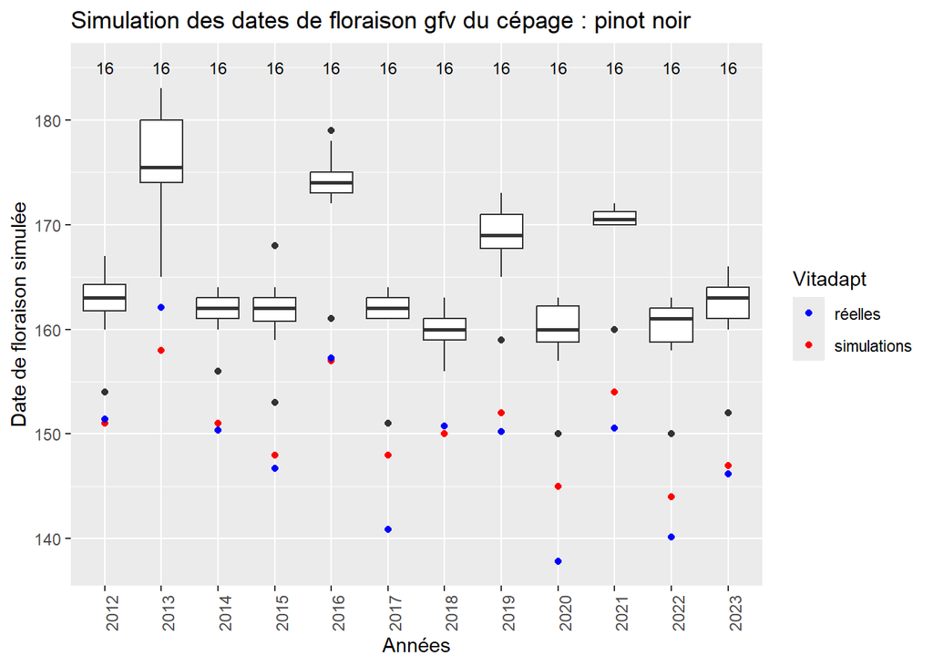

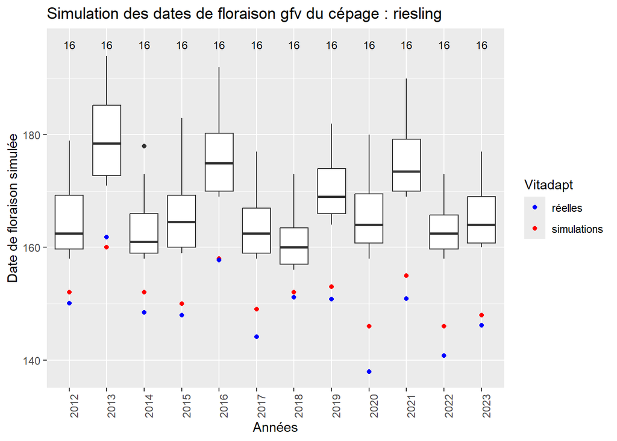